# Geospatial Analysis with R

Class 19

Lyndon Estes & Zhiwen Zhu

November 6, 2017

# Today

- Exercises from readings
- Unit wrap-up

# Exercises from reading

### Rapporteurs

```r
set.seed(1001)
sel_names <- student_names3[sample(1:length(student_names3), size = 5)]
sel_names
```

```
## [1] "Zachary Peloquin"    "Kelsey Meisenhelder" "Jeanie Lai"
## [4] "Yiwen Hu"            "Haoyu Li"
```

```r
student_names4 <- student_names3[!student_names3 %in% sel_names]
set.seed(1001)
sel_names <- student_names4[sample(1:length(student_names4), size = 4)]
sel_names
```

```
## [1] "Youtao Lin"  "Cory Hertog" "Will Heikes" "Wenle Jiang"
```

# Exercise Datasets

```r
library(geospaar)
library(raster)
zamr <- raster(x = extent(districts), crs = crs(districts), res = res(dem))
values(zamr) <- 1:ncell(zamr)
zamr_alb <- projectRaster(from = zamr, res = 1000, crs = crs(roads),
                          method = "ngb")
demalb <- projectRaster(from = dem, to = zamr_alb)  # default is bilinear

chirpsz <- mask(x = chirps, mask = districts)
districts$ID <- 1:length(districts)
raintot <- calc(chirpsz, sum)

raintotalb <- projectRaster(from = raintot, res = 5000, crs = crs(roads))
names(raintotalb) <- "rain"

zamprecalb <- projectRaster(from = zamprec, to = raintotalb)
names(zamprecalb) <- "rain"
elev <- resample(aggregate(x = demalb, fact = 5), y = raintotalb)
```

# Exercise 14

Crop `demalb` down to the extent of district 42 (bear in mind that `districts` needs to be in the same projection as `demalb`, so transform it first). Then calculate slope, aspect, and TPI on the cropped DEM. Plot the results so that they appear in 3 side by side panels

```r
dist42alb <- spTransform(districts[42, ], crs(roads))
demalb42 <- crop(demalb, y = dist42alb)

vars <- c("slope", "aspect", "tpi")
terrvars <- stack(lapply(1:length(vars), function(x) {
  tv <- terrain(x = demalb42, opt = vars[x], unit = "degrees")
}))
names(terrvars) <- vars

# par(mfrow = c(1, 3))
# for(i in 1:3) plot_noaxes(terrvars[[i]], main = vars[i])
plot_noaxes(terrvars2, nc = 3, nr = 1)  # Ali's better solution
```

[output not shown]

# Exercise 15

Using just the code in blocks 1-3 (in section 6.3 of reading) as your template, create IDW interpolations using the original 1000 randomly sampled points, and then two new ones based on 1) 500 and 2) 250 randomly selected points. Create a 4 panel plot by a) stacking, in this order, `raintotalb`, the 1000 point IDW, the 500 point IDW, and the 250 IDW, b) naming the layers of the stack, c) using a single call to plot_noaxes. Use “zlim = c(0, 150)”. There are two ways of doing this: i) the hard way, by copying, pasting, and changing code blocks 2-3 for each version of the IDW; ii) the elegant way, by creating the three IDWs in an lapply.

```r
raintotalb <- projectRaster(from = raintot, res = 5000, crs = crs(roads))
names(raintotalb) <- "rain"
r <- raster(extent(raintotalb), res = res(raintotalb), crs = crs(raintotalb),
            vals = 1)

set.seed(1)
idws <- lapply(c(1000, 500, 250), function(x) {
  rainsamp <- sampleRandom(raintotalb, size = x, xy = TRUE)
  rainsamp <- as.data.frame(rainsamp)
  invdist <- gstat(id = "rain", formula = rain ~ 1, locations = ~x + y,
                   data = rainsamp)
  invdistr <- interpolate(object = r, model = invdist)
  invdistrmsk <- mask(x = invdistr, mask = raintotalb)
})

s <- stack(raintotalb, stack(idws))
names(s) <- c("rain", "idw1000", "idw500", "idw250")
plot_noaxes(s, zlim = c(0, 150))
```

[output not shown]

# Exercise 16

Select districts 15, 20, 25, 30, 35, 40, 45, and 50 out of `districts`. Convert the resulting subset of districts to Albers projection. Use `distance` or `distanceFromPoints` to calculate the distances from any point in Zambia to the centroids of those selected districts

```r
dists_ss <- spTransform(districts[seq(15, 50, 5), ], crs(roads))

# Method 1
randsampr <- rasterize(rgeos::gCentroid(dists_ss, byid = TRUE), y = raintotalb)
ptdistr2 <- distance(randsampr)
ptdistrmsk2 <- mask(ptdistr2, raintotalb)
plot(ptdistrmsk2)

# Method 2
ptdistr <- distanceFromPoints(object = raintotalb,
                              xy = rgeos::gCentroid(dists_ss, byid = TRUE))
ptdistrmsk <- mask(ptdistr, raintotalb)
plot(ptdistrmsk)
```

[output not shown]

# Exercise 17

Redo the maps above (made in section 6.5), but use a new random draw of just 25 points to collect the predictors. Redo it again, but this time use the district centroids (think `gCentroid`) as the points (`pts`), bearing in mind that you have to extract a rainfall value from zamprecalb as an extra step in this case. How much more poorly do these two models do than the one with denser observations?

```r
# Block 2
set.seed(1)
switch <- 1  # change switch to 2 to model rainfall from district centroids
if(switch == 1) {  # collect random sample for model
  pts <- sampleRandom(x = zamprecalb, size = 25, sp = TRUE)  # turn on
} else if(switch == 2) {  # used district centroids to collect values for model
  pts <- gCentroid(spgeom = spTransform(districts, crs(roads)), byid = TRUE)
  pts$rain <- extract(x = zamprecalb, y = pts)
}
pts$elev <- extract(x = elev, y = pts)
pts <- as.data.frame(pts)

# Block 4
rain_lm <- lm(rain ~ x + y + elev, data = pts)
summary(rain_lm)

# Block 5
xs <- xFromCell(object = raintotalb, cell = 1:ncell(raintotalb))
ys <- yFromCell(object = raintotalb, cell = 1:ncell(raintotalb))
x <- y <- raintotalb
values(x) <- xs
values(y) <- ys

# Block 6
predst <- stack(x, y, elev)
names(predst) <- c("x", "y", "elev")
predrainr <- predict(object = predst, model = rain_lm)

# Block 7
s <- stack(zamprecalb, predrainr, (predrainr - zamprecalb) / zamprecalb * 100)
mae <- round(cellStats(abs(zamprecalb - predrainr), mean), 1)  # mean absolute error
pnames <- c("'Observed' Rainfall", "Predicted Rainfall", "% Difference")
par(mfrow = c(1, 3), mar = c(0, 0, 1, 4))
for(i in 1:3) {
  plot_noaxes(s[[i]], main = pnames[i])
  if(i %in% 1:2) points(pts$x, pts$y, pch = 20, cex = 0.1, col = "grey70")
  if(i == 3) {
    mtext(side = 1, line = -3, cex = 0.8,
          text = paste("Mean abs err =", mae, "mm"))
  }
}
```

[output not shown]

# What we covered in Unit 2 - *Vectors*

- reading/writing
- `sp` data classes/structures
- create your own spatial objects
- projections
- calculate spatial properties
- subsetting
- intersects/intersection (extract/over)
- differencing/erasing
- unions
- buffering

# What we covered in Unit 2 - *Rasters*

- reading/writing
- raster structures (Layer/Brick/Stack)
- create your own dummy rasters
- projections/transformations
- aggregating/disaggregating/resampling
- raster statistics, global, local, Z-dimension
- algebra
- subsetting: layer extraction/cropping/masking
- basic classification/categorization
- distance
- terrain analysis

# What we covered in Unit 2 - *Vectors + Rasters*

- sampling and extraction
- vectors to rasters and back again
- modeling, spatial and non-spatial
  - interpolation, kriging, regression prediction onto rasters
- combined plotting

# What we did not cover

- more advanced spatial modeling capabilities
  - distribution modelling (`dismo`), point pattern analysis (`spatial`, `splancs`), spatial regression models
  - geostatistics (`nlme`, `spdep`, `splm`)
- Simple features (`sf`) replacing S4 `Spatial*` classes provided by `sp`
- Remote sensing oriented capabilities
  - Handling very large data (`gdalUtils`, `doMc`, `foreach`, using `raster` with chunks)
  - classes for satellite images: `landsat`, `modis`, and `satellite` packages
  - visualization: `rasterVis`
  - classifications
    - unsupervised and supervised (e.g. `randomForest`)
    - More advanced machine learning: see CRAN Machine Learning Task View[link](https://cran.r-project.org/web/views/MachineLearning.html)
  - all in one: `RSToolbox`

# What we did not cover 2

- Use R to access other GIS
  - `rpostgis`, `spgrass6`/`rgrass7`, `RSAGA`, `RPyGeo`, `RQGIS`
- See Cran Spatial Task View link for much more
- Invalid geometries

# Invalid geometries

```r
library(sp)
crds <- data.frame(x = c(1, 2, 2, 1, 1), y = c(1, 1, 2, 1, 0.5))
p <- Polygons(srl = list(Polygon(coords = crds)), ID = "1")
spoly <- SpatialPolygons(Srl = list(p))
rgeos::gIsValid(spoly)
```

```
## [1] FALSE
```

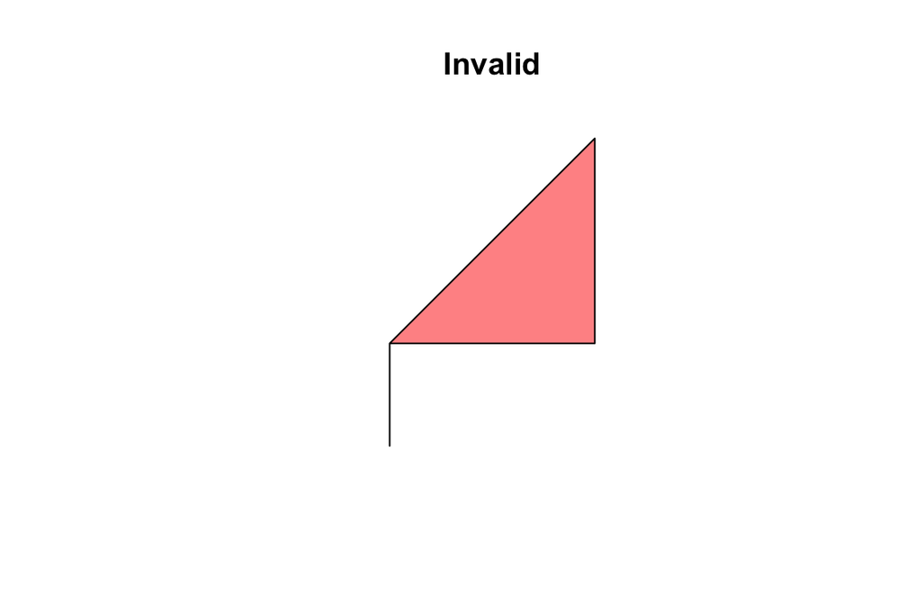

```r
plot(spoly, col = rgb(1, 0, 0, alpha = 0.5), main = "Invalid")
```

# Invalid geometries 2

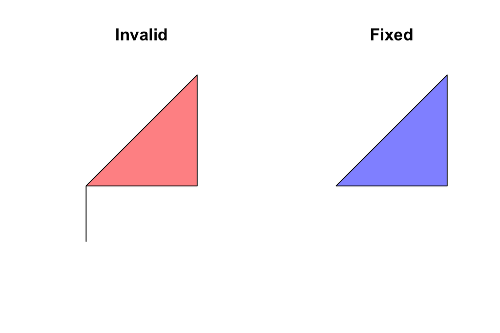

```r
spolyfix <- rgeos::gBuffer(spoly, width = 0)  # sometimes fixes it

par(mfrow = c(1, 2))
plot(spoly, col = rgb(1, 0, 0, alpha = 0.5), main = "Invalid")
plot(spolyfix, col = rgb(0, 0, 1, alpha = 0.5), ylim = bbox(spoly)[2, ],
     main = "Fixed")
```

# `sp` versus `sf`

```r
fnm <- system.file("extdata/districts.shp", package = "geospaar")
system.time(dists_sf <- sf::read_sf(dsn = fnm))
```

```
##    user  system elapsed
##   0.097   0.056   0.233
```

```r
system.time(districts <- rgdal::readOGR(dsn = fnm, layer = "districts",
                                        verbose = FALSE))
```

```
##    user  system elapsed
##   0.800   0.007   0.807
```

# `sp` versus `sf` 2

```r
dists_sf
```

```
## Simple feature collection with 72 features and 1 field
## geometry type:  POLYGON
## dimension:      XY
## bbox:           xmin: 21.99953 ymin: -18.0762 xmax: 33.70588 ymax: -8.226213
## epsg (SRID):    4326
## proj4string:    +proj=longlat +datum=WGS84 +no_defs
## # A tibble: 72 x 2
##         distName          geometry
##            <chr>  <simple_feature>
##  1       Chadiza <POLYGON ((32...>
##  2         Chama <POLYGON ((32...>
##  3       Chavuma <POLYGON ((23...>
##  4      Chibombo <POLYGON ((28...>
##  5       Chiengi <POLYGON ((29...>
##  6 Chililabombwe <POLYGON ((27...>
##  7       Chilubi <POLYGON ((30...>
##  8      Chingola <POLYGON ((27...>
##  9      Chinsali <POLYGON ((32...>
## 10       Chipata <POLYGON ((32...>
## # ... with 62 more rows
```

```r
districts
```

```
## class       : SpatialPolygonsDataFrame
## features    : 72
## extent      : 21.99953, 33.70588, -18.0762, -8.226213  (xmin, xmax, ymin, ymax)
## coord. ref. : +proj=longlat +datum=WGS84 +no_defs +ellps=WGS84 +towgs84=0,0,0
## variables   : 1
## names       : distName
## min values  :  Chadiza
## max values  :  Zambezi
```

# `sp` versus `sf` 3

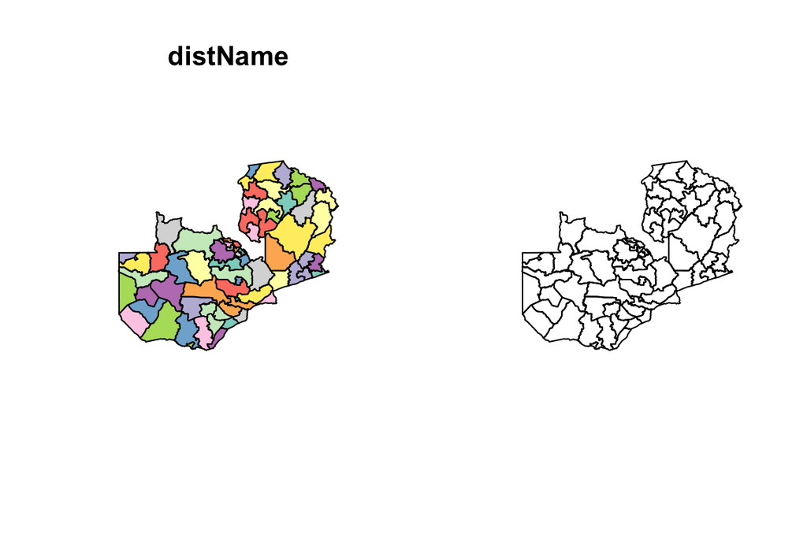

```r
par(mfrow = c(1, 2))
plot(dists_sf)
plot(districts)
```

```r
dists_sf$ID <- 1:nrow(dists_sf)
```